# Tourism Forecasting: a Time Series Analysis

Ilaria Berardi

Spring term 2025

# Section 1:Introduction

## 1.1 The Role of Tourism in Economic Growth

The tourism industry plays a vital role in the economic growth of a country. It includes all the businesses and companies that provide services to and for travellers, from the accommodation sector (including hotels, resorts, and Airbnb rentals), to the food and beverage industry (which benefits greatly from high tourism periods), to the retail sector and also to the transportation sector. Tourism creates so many different jobs and is considered one of the main income sources for many developing countries. As the World Tourism Organization (UNWTO) states, *“Today, the business volume of tourism equals or even surpasses that of oil exports, food products, or automobiles”.*

## 1.2 The Importance of Forecasting in Tourism

As in all businesses, **forecasting** is crucial in supporting a sustainable development and growth of the tourism industry. A close to accurate prediction of future trends and patterns of tourism data would ensure effective and informed business decisions, year-over-year planning, enhancement of consumer satisfaction, and development of data-driven strategies to optimise profit.

## 1.3 Objectives

My aim is to analyse a **time series** dataset of **monthly international tourist arrivals in Italy** from **January 2018 to August 2024**, covering a period of six years and eight months (80 data points in total).

My interest in this topic stems from a **personal connection to the industry**. My family runs a business that relies heavily on tourism in Italy, and I have been actively involved in supporting and working within it.

This article will explore **trends, seasonality patterns, and external factors** influencing tourism in Italy, including the **sharp downfall during the COVID-19 pandemic in 2020**.

This article aims to cover the following time series techniques:

- **Using the Prophet package in R Studio** to forecast the number of international tourists coming to Italy over different time frames
- **Observing the COVID-19 pandemics impact** on tourist arrivals and its subsequent recovery period
- **Decomposing the time series data** to analyze each component individually
- **Understanding off-season and high-season periods** that occur repeatedly within a year (**seasonality trends**)
- **Applying transformations** to the data to improve analysis and accuracy (such as Logarithm transformation for parsimony)
- **Checking for heteroscedasticity** using the **Breusch–Pagan Test**
- **Fitting a Linear Regression model**

## 1.4 Data

The data has been imported from *Statista*. **Source:** *Banca d’Italia*.[Monthly Number of International Tourist Arrivals in Italy - Statista](https://www.statista.com/statistics/1155499/monthly-number-of-international-tourist-arrivals-in-italy/)

The data is monthly, with a total of 80 observations. The initial month is January 2018 and the last one is in August 2024. While it could be argued that more data points would improve the robustness of the forecast and the accuracy of the analysis, this data set still captures trends, seasonality patterns that repeatedly occur during a year, and cyclicity, meaning periodic behaviour with less clearly understood periodicity (e.g. the fall due to COVID-19). It is good to keep in mind that it could be a limitation, although this time series data spans through 6 years and 8 months, which is a vast enough time span to provide us with meaningful insights to uncover!

```r
# Firstly, we load the relevant libraries.
# As we go, a few useful libraries will be loaded.
library(readxl)
library(dplyr)
library(ggplot2)
library(prophet)
library(lubridate)
```

We import our data into R Studio.

```r
# Importing the data from a saved Excel sheet
Tourism_data <- read_excel("/Users/madeline/Desktop/Mathematics Uni/year 3 2024-2025/Semester 2/Time Series /Coursework1Template /data/tourism_data.xlsx", sheet = "Data")
```

```r
# Renaming the columns
colnames(Tourism_data) <- c("ds", "y")

# We convert 'ds' column to the date format
Tourism_data$ds <- as.Date(paste0("01-", Tourism_data$ds), format = "%d-%b %Y")

# Convert 'y' column to numeric format
Tourism_data$y <- as.numeric(Tourism_data$y)

# I want to remove missing values denoted by NA
Tourism_data <- Tourism_data %>%
    filter(!is.na(ds) & !is.na(y))

# Check that data is cleaned and in the correct format
str(Tourism_data)
```

```
## tibble [80 × 2] (S3: tbl_df/tbl/data.frame)
##  $ ds: Date[1:80], format: "2018-01-01" "2018-02-01" ...
##  $ y : num [1:80] 5573 4951 6115 7381 8659 ...
```

```r
# Preview of our data
head(Tourism_data)
```

```
## # A tibble: 6 × 2
##   ds             y
##   <date>     <dbl>
## 1 2018-01-01  5573
## 2 2018-02-01  4951
## 3 2018-03-01  6115
## 4 2018-04-01  7381
## 5 2018-05-01  8659
## 6 2018-06-01  9410
```

Our data is in the correct format: a data frame with columns ‘ds’(year) and ‘y’(international tourist arrivals), we shall proceed!

```r
# We first want to convert the data frame into a time series object (ts)
# The frequency is 12 as it is monthly data

Tourism_ts <- ts(Tourism_data$y,
                      start = c(2018, 1),
                      frequency = 12)
```

# Section 2: Visualising the Data

This is a first visual inspection of the time series data. It is important to always make a first visual analysis of the data we have by plotting it, it is a crucial first investigatory step of **Exploratory Data Analysis**.

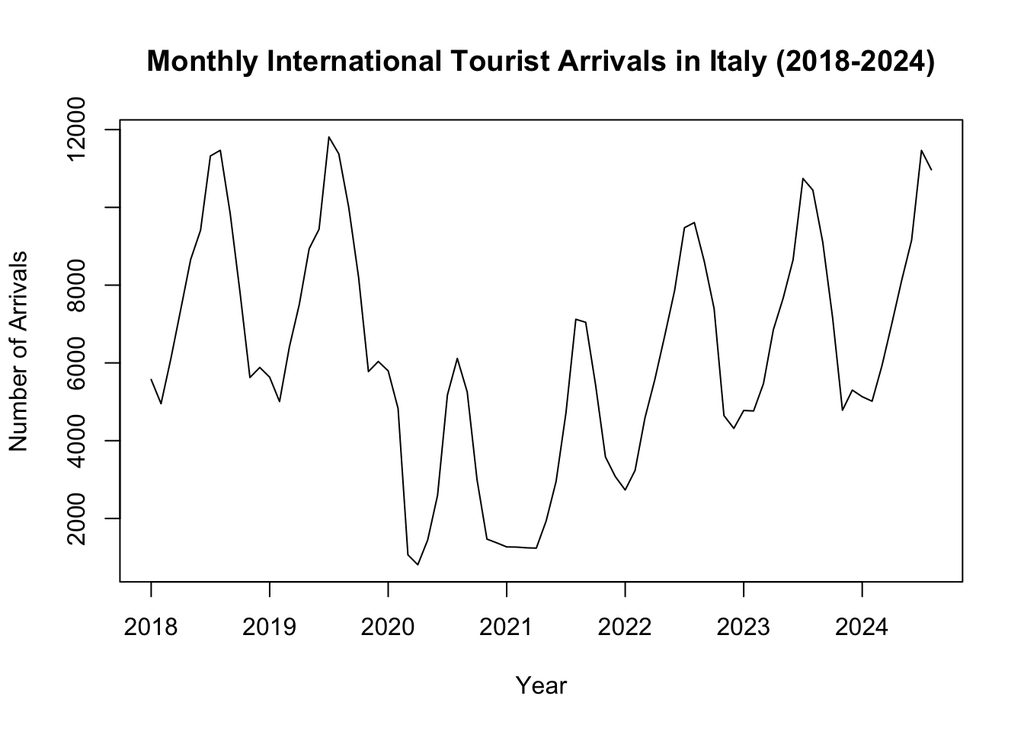

```r
plot.ts(Tourism_ts,
        xlab = "Year",
        ylab = "Number of Arrivals",
        main = "Monthly International Tourist Arrivals in Italy (2018-2024)")
```

**Interpretation:** The number of tourist arrivals in Italy fluctuates over time. The plot displays recurring peaks and falls during the years, suggesting a **significant seasonality effect**.

This was expected as tourism generally has its **off-seasons** and **high-seasons**, and price increases or decreases depending on what season it is. For example, generally summer months such as **July** and **August** or autumn months such as October are high season months for tourism in Italy.

The plot confirms this as we observe that most years from the plot have **peaks** roughly in the middle of the year, which is the summer period (June, July, August).

A notable interruption to this clear recurring seasonality pattern is visible: there is a **steep and sudden decline** in arrivals in the years **2020-2021**. This is interesting, as it is the direct consequence of the 2020 **global pandemic: COVID-19**, which led to global travel restrictions. The lowest number of arrivals of this time series occurs during this sharp fall.

This two year decline is an example of a cyclic element in the time series, as it is not a repeating seasonality pattern, but rather a long-term fall due to an external reason, in this case the pandemic. During the following years, when the pandemic stopped spreading so drastically, a gradual recovery period is recognizable. The number of international arrivals starts increasing again since the drop from the year 2021 onwards.

This recovery period follows the same clear seasonality pattern of before (peaks in the middle of the years), however, some fluctuations imply that tourism did not immediately return to pre-pandemic levels, it took a while to normalise. From 2021 to 2024 we can see a constant growth in tourist arrivals, peaks each year get higher and higher, with the tallest post-pandemic peak almost reaching the highest pre-pandemic peak. This suggests that tourism will probably grow by a small percentage each year.

# Section 3: Forecasting with Prophet

Having visually inspected our time series data, we are now ready and excited for some forecasts!

## 3.1 Preparing the data

We create and fit a forecasting model using the Prophet package.

```r
library(zoo)
model = prophet(Tourism_data)
```

Prophet models time series data using the **additive model**. Lets break this model down, explaining what each component is:
$$X_t = m_t + S_t + Y_t, \quad t = 1, \dots, n$$
where:

- $X_t$ is our **original time series**
- $m_t$ is the **trend**, *an underlying non-random pattern of evolution.*
- $S_t$ is the **seasonality component**, *an underlying non-random periodic pattern with a clearly understood period.*
- $Y_t$ is the **residual error**,*what is left of our time series once we have removed all the factors above. e.g. Such as disruptions from the COVID-19 pandemic.*

```r
 # Convert the time series object to a vector of dates
 Tourism_time <- time(Tourism_ts)

 # Convert numeric time index to "Year-Month" format
 Tourism_dates <- as.yearmon(Tourism_time)

# Create a data frame
 Tourism_df <- data.frame(
     ds = as.yearmon(time(Tourism_ts)),
     y = as.numeric(Tourism_ts)
 )

 head(Tourism_df)
```

```
##         ds    y
## 1 Jan 2018 5573
## 2 Feb 2018 4951
## 3 Mar 2018 6115
## 4 Apr 2018 7381
## 5 May 2018 8659
## 6 Jun 2018 9410
```

## 3.2 2-year Forecast

Prophet has the built-in function `plot()` to plot the predictions and display the following results.

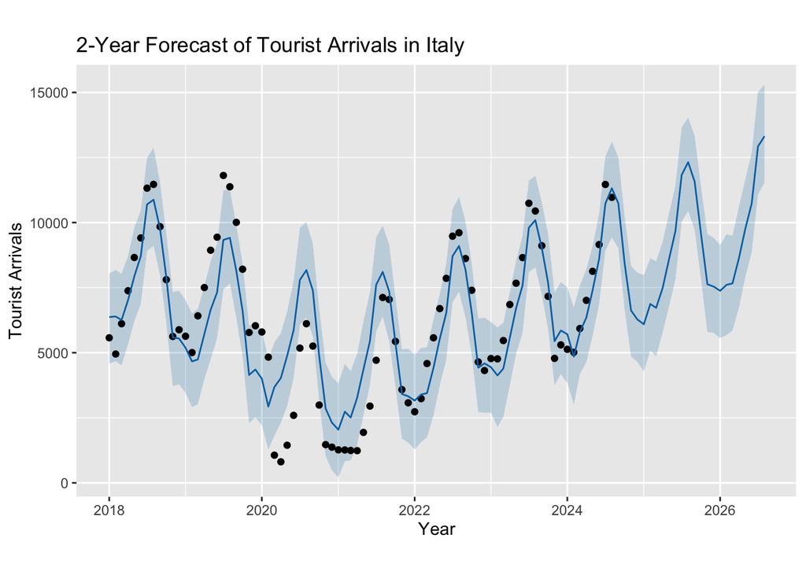

```r
 # Create a data frame for future predictions for a period of 24 months
 future <- make_future_dataframe(model, periods = 24, freq = "month")

# Predict future values
#The predict method will assign each row in future a predicted value which it names yhat.
 forecast = predict(model, future)

# Create Plot with forecast data
forecast_plot=plot(model,forecast)
 forecast_plot +
     ggtitle("2-Year Forecast of Tourist Arrivals in Italy") +
     xlab("Year") +
     ylab("Tourist Arrivals")
```

This looks like a feasible 2-year forecast. As we can see, in black, we have the actual observations, whilst the blue line represents the predicted number of international tourists arriving in Italy. The shaded blue region around this line indicates the uncertainty interval, the thicker the shaded region the greater the uncertainty in predictions. The forecast predicts an **overall increasing trend** and a **continuation of the clear seasonality pattern** previously analysed. It looks like tourism will keep increasing year after year with the usual highs in the summer months and lows in the winter period.

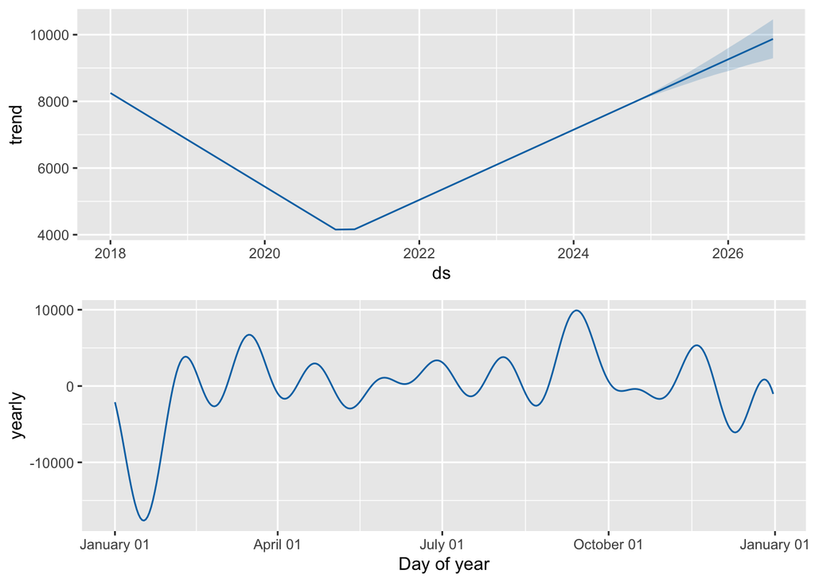

```r
prophet_plot_components(model, forecast)
```

The `prophet_plot_components()` function offers a more detailed breakdown of the analysis, into trend and yearly seasonality. We can see a “v” shaped graph for the trend, with an initial steep decline followed by a linear increase.This plot clearly presents how disruptive COVID-19 has been in the world of tourism, as people were not allowed to travel any more. This was a hugely important historical moment that has influenced so many industries, especially the tourism one, and especially in Italy. However, after this terrible **downfall in 2020**, we can see a **rising trend** in arrivals (which also seems to become **linear**).

The plot below captures **recurring seasonal patterns** which occur within a year, (note how the x-axis is **one year only**). Steep fluctuations in arrivals are seen for individual months. It confirms that generally, high peaks of tourism are experienced in warmer periods, from spring time, to summer time, to autumn time ending this high-season period in October. Whereas, falls occur during the winter period, with big falls in January, which seems to be the month with fewest amount of tourists visiting Italy.

**Economic Strategy:** Lower the prices/make offers or promotions during off-season months, and increase the prices during high-season months.

## 3.3 5-year Forecast

Now, lets look at a longer-term prediction of five years, with another forecast plot! This may be useful for businesses who want to make a 5 year plan. But, we always keep in mind that we cannot totally rely on these forecasts as there may be high uncertainty or an external factor may always suddenly happen, like an economic crisis.

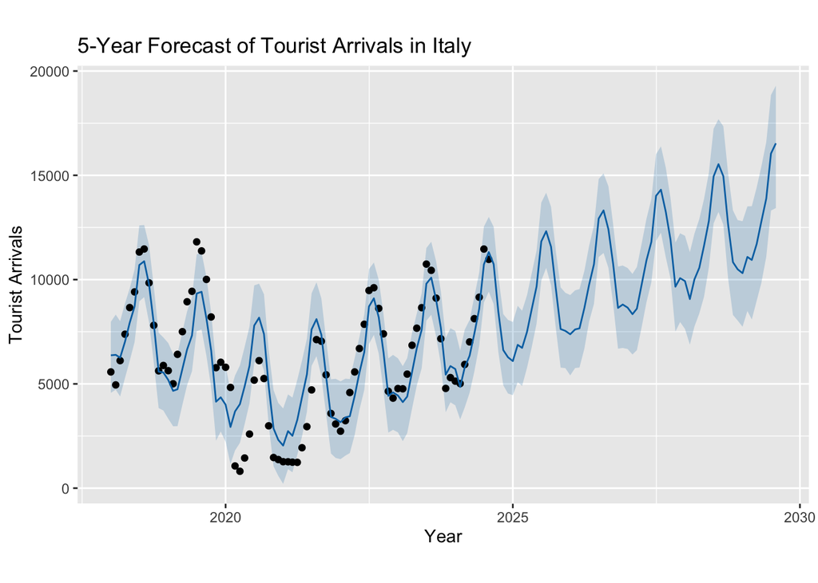

```r
 # Create a data frame for future predictions for a 60 month period
future2 <- make_future_dataframe(model, periods = 60, freq = "month")
 # Predict future values
 forecast2 = predict(model, future2)
 forecast_plot2=plot(model,forecast2)
 # Create plot
 forecast_plot2 +
     ggtitle("5-Year Forecast of Tourist Arrivals in Italy") +
     xlab("Year") +
     ylab("Tourist Arrivals")
```

This extended prediction period (until 2029), shows a constant yearly growth and an increase in tourist arrivals in Italy. It is predicted that in 2029 the number of tourists will be higher than the number before COVID-19 happened. If the forecast is accurate, this is very positive news for businesses in the tourism sector, as a greater number of tourists in Italy is expected yearly. Most of all, this means that this is a sector which is constantly growing and evolving, and this is of fundamental importance, as it is never a good idea to work in a sector which is predicted to fall or be replaced. This is interesting especially for students who just graduated and are about to embark themselves into the real world and choose a career path.

The typical seasonality patterns appear to persist consistently over the years.

The uncertainty region expands over time, which is expected since predictions become less certain the further they extend into the future.

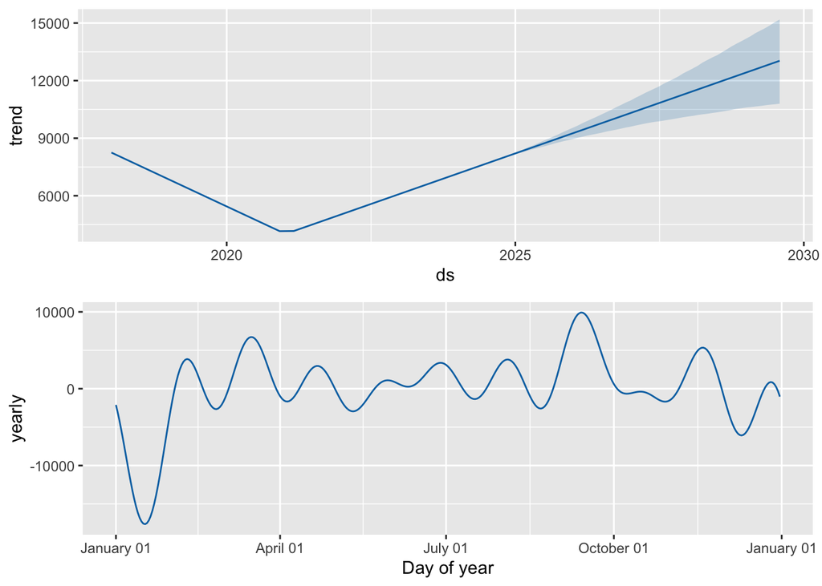

```r
 prophet_plot_components(model, forecast2)
```

The prediction says that the upward trend will persist even beyond the year 2026 until the year 2029. However, one can notice that in years greater than 2026, the uncertainty region widens as time passes by. This is to warn us that longer-term future predictions are obviously less certain than shorter-term ones, and confidence intervals expand.

Seasonality patterns stay consistent, with the same peaks and fall in January.

Overall, the model predicts a steady recovery and growth in international tourism over the next five years.

# Section 4: Decomposition of the Additive Model

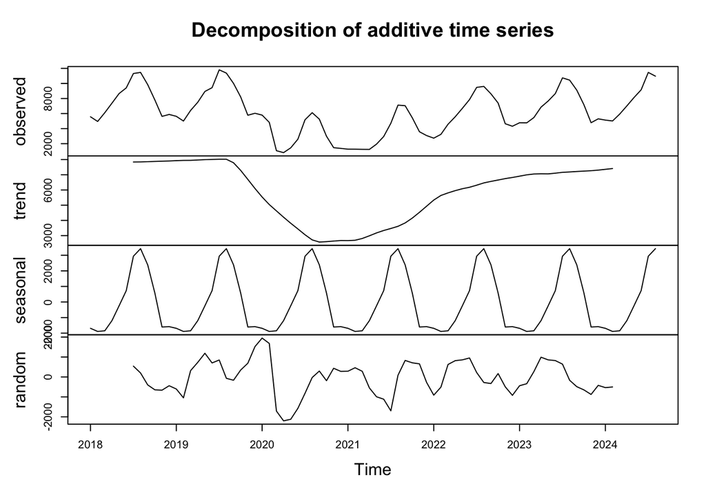

```r
Tourism_ts <- ts(Tourism_df$y, start = c(2018, 1), frequency = 12)
# Decomposing the additive model into its components: observed, trend, seasonal, and random.
 Tourism_decomposition <- decompose(Tourism_ts, type = "additive")
 # Create the plot to visualise components
 plot(Tourism_decomposition)
```

On our top panel we have our observed data, what we have been plotting all along. Below we have the trend displayed. On our third panel we have the seasonal signal, without the irregular fluctuations involved. Our last panel shows the random signal, regular fluctuations in the data that cannot be accounted for by the other components.

We expected to see this. The trend has a decline and then an upwards rise post-COVID-19. The random component shows large deviations during 2020, because of the pandemic, implying that this was a sudden irregular fluctuation caused by a sudden, unexpected event. After 2021, the residuals are more stable and around zero. The seasonal component plot shows the one big peak that occurs yearly during the late spring - summer period (during the middle of the year). However, the plot presents a seasonal component that is definitely too perfect to be real! Real-world data is not so predictable, constant and repetitive. Real-world data is normally imperfect and messy, and it does not have these regular oscillations that are exactly the same every year. So we need to remind ourselves that this model’s estimate must not be totally reflective of the real patterns of this data.

**Remember:** Most time series decomposition approaches have the underlying assumption that the seasonal component is the same over time.

## 4.1 Seasonality Effect on Data

The two following plots illustrate the original time series (with seasonality) against the time series after removing the seasonal effects. My goal is to explore to what extent does seasonality influence this data set, by comparing both plots and checking how much they differ.

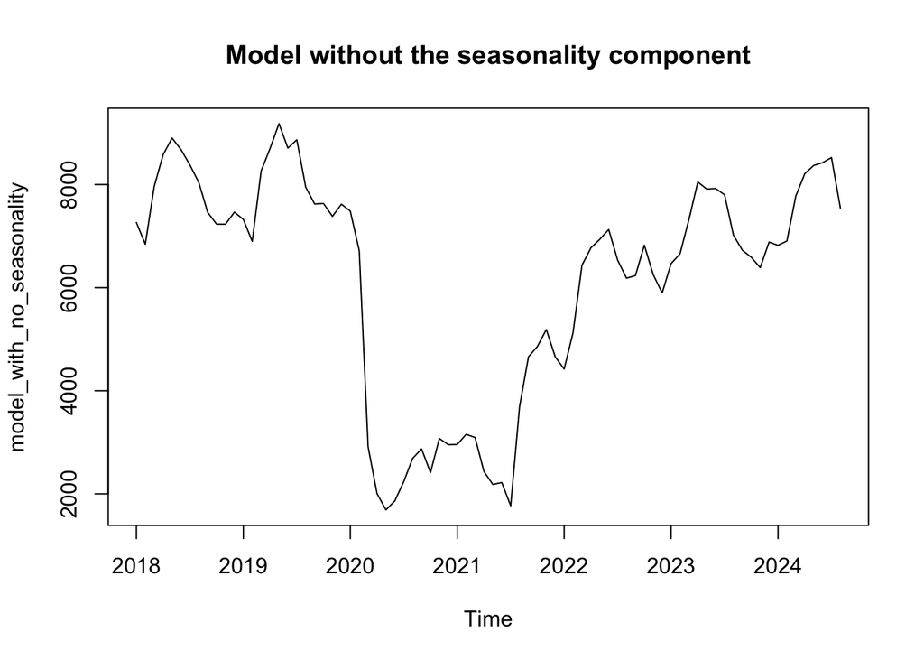

```r
# Removing the seasonality component from the original model
# This version removes the seasonal component, leaving only the underlying trend and random component.
model_with_no_seasonality= Tourism_ts - Tourism_decomposition$seasonal
plot(model_with_no_seasonality,
     main="Model without the seasonality component")
```

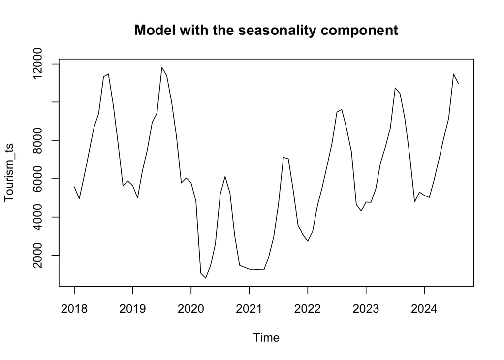

```r
# plot the original time series
plot(Tourism_ts,
     main="Model with the seasonality component")
```

**Comparison and Interpretation:** Comparing these two plots, one notices that they are quite different from one another. Their shapes differ. If their shape was very similar and did not change much, it would indicate that seasonality has little impact on the data. Yet, in this case, seasonality seems to affect the data to a high extent.This outcome was expected, as tourism is heavily influenced by the popularity of certain seasons. It is also noticeable that removing seasonality, the random component and the trend are more evident, and the great fall of tourists due to the pandemic is more pronounced.  
Hence, seasonality does significantly influence tourism trends

# Section 5: Transformations

## 5.1 Box Cox Transformation

Transforming the data is something we can do to address the issue of heteroskedasticity (when variance of the data varies through time). *Instead of analyzing $x$ directly, we consider a transformed version:*

$$x_{\text{new}} = f(x)$$

*where $f(x)$ is a suitable function chosen to stabilize variance.*

$$\text{BoxCox}(x_t) =
\begin{cases}
\frac{x_t^{\lambda} - 1}{\lambda}, & \lambda \neq 0, \\
\log x_t, & \lambda = 0.
\end{cases}$$

```r
# Box Cox transformation
library(forecast)
```

We want to find the optimal parameter $\lambda$ in the Box Cox transformation by maximum likelihood using past data.

```r
(lambda = forecast::BoxCox.lambda(Tourism_ts))
```

```
## [1] 0.9204839
```

The sign of $\lambda$ will indicate whether the variance is increasing or decreasing.

0.9204839 is close to 1. This suggests that my data is close to a normal distribution and does not have an issue with heteroscedasticity.

But I will make these transformations anyway, in order to show what could be done to deal with an issue with heteroscedasticity in your data.

```r
Tourism_ts_BC = BoxCox(Tourism_ts, lambda)
```

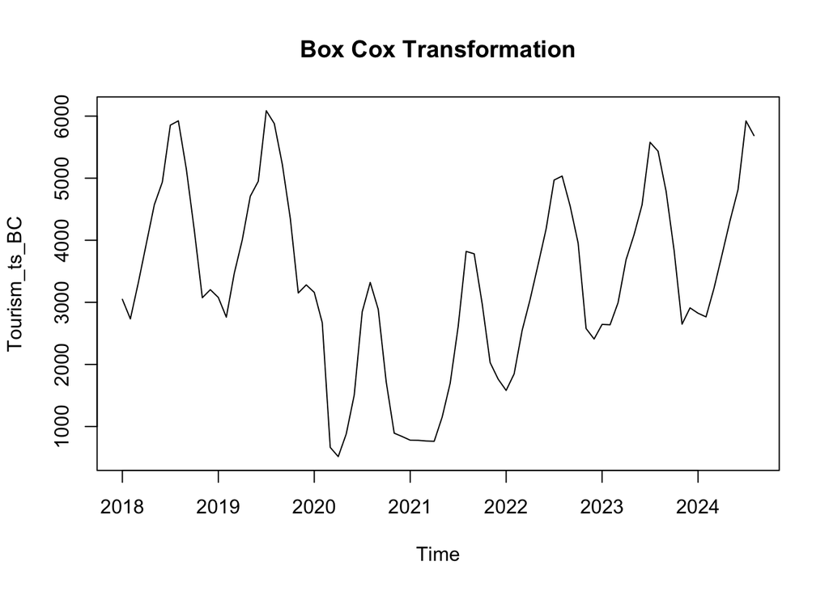

```r
# Create the plot
plot(Tourism_ts_BC,
     main = "Box Cox Transformation")
```

## 5.2 Log Transformation

Log Transformation is simpler than Box Cox Transformation. Data Scientists tend to use the log transformation, motivated by the *principle of parsimony*.

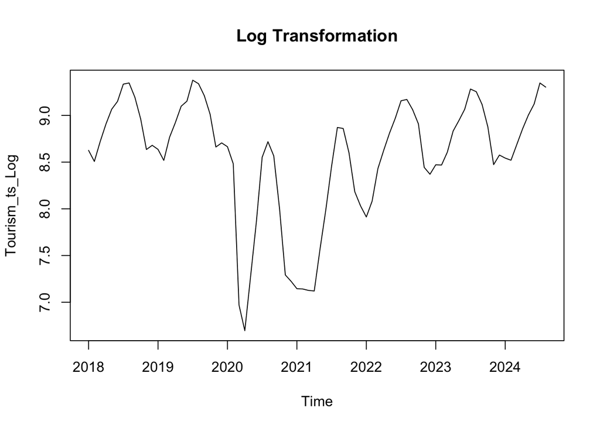

```r
#Log transformation
Tourism_ts_Log = log(Tourism_ts)
# Create the plot
plot(Tourism_ts_Log,
     main = "Log Transformation")
```

# Section 6: Testing for Heteroscedacity

Does the time series seem homoscedastic or heteroscedastic?

## 6.1 Breusch Pagan test

$$H_0: \text{the time series is homoscedastic} \\
H_1: \text{the time series is heteroscedastic}$$

```r
# Perform Breusch-Pagan test
library(lmtest)
```

```r
lmtest::bptest(Tourism_ts~time(Tourism_ts))
```

```
##
##  studentized Breusch-Pagan test
##
## data:  Tourism_ts ~ time(Tourism_ts)
## BP = 0.80785, df = 1, p-value = 0.3688
```

The p-value is 0.3688, which is much greater than 0.05. So, we **fail to reject $H_0$.**The original time series does not have significant heteroscedasticity, the variance does not change too much through time.

```r
lmtest::bptest(Tourism_ts_BC~time(Tourism_ts_BC))
```

```
##
##  studentized Breusch-Pagan test
##
## data:  Tourism_ts_BC ~ time(Tourism_ts_BC)
## BP = 0.88297, df = 1, p-value = 0.3474
```

The p-value is 0.3474, which is much greater than 0.05. So, we **fail to reject $H_0$.**The original time series does not have significant heteroscedasticity.

```r
lmtest::bptest(Tourism_ts_Log~time(Tourism_ts_Log))
```

```
##
##  studentized Breusch-Pagan test
##
## data:  Tourism_ts_Log ~ time(Tourism_ts_Log)
## BP = 1.4825, df = 1, p-value = 0.2234
```

The p-value is 0.2234, which is much greater than 0.05. So, we **fail to reject $H_0$.**The original time series does not have significant heteroscedasticity.

Breusch-Pagan test results for all three

| Transformation | BP_statistic | Degrees_of_freedom | P_value |
| --- | --- | --- | --- |
| Original | 0.80785 | 1 | 0.3688 |
| Box-Cox | 0.88297 | 1 | 0.3474 |
| Log | 1.48250 | 1 | 0.2234 |

All p-values are greater than 0.05, meaning that there is not strong evidence that the data is heteroscedastic.

# Section 7: Linear Regression

Finally, in the last section of our time series investigation we will fit a linear regression model to our time series tourism data.

Linear regression is one of the most powerful machine-learning tools for analysing data and predicting future outcomes. It is a supervised statistical modelling technique that not only determines whether a significant relationship exists between variables but also quantifies the strength of their influence on a dependent variable.

In our case, we want to fit a straight line to predict the number of tourist arrivals (y) based on the time variable (ds).

```r
library(ggplot2)
```

```r
linear_model <- lm(y ~ ds, data = Tourism_data)
summary(linear_model)
```

```
##
## Call:
## lm(formula = y ~ ds, data = Tourism_data)
##
## Residuals:
##     Min      1Q  Median      3Q     Max
## -5326.4 -1487.5  -325.8  2168.4  5696.6
##
## Coefficients:
##              Estimate Std. Error t value Pr(>|t|)
## (Intercept) 4.670e+03  8.801e+03   0.531    0.597
## ds          7.983e-02  4.695e-01   0.170    0.865
##
## Residual standard error: 2951 on 78 degrees of freedom
## Multiple R-squared:  0.0003706,  Adjusted R-squared:  -0.01245
## F-statistic: 0.02892 on 1 and 78 DF,  p-value: 0.8654
```

## 7.1 Coefficients

The slope’s coefficient is 7.983e-02 = 0.07983. This value is very close to zero, which means that time has almost no impact on the number of tourist arrivals in a linear trend.

## 7.2 R Squared

The R-squared value is 0.0003706. This implies that the model explains only 0.037% of the variance variability in the number of tourist arrivals, so it does not have much predictive power.However, this might be because tourist arrivals can depend on numerous factors which are not taken into account in our model.

This Linear regression model is not very useful for our prediction, it does not explain the variation in tourist arrivals and has little predictive power. Other statistical techniques would be more efficient.

# Section 8: Conclusion

Just like all data analysis I have explored, there is always a balance between aspects that prove to be less useful, such as Linear Regression in this case, and those that offer valuable insights. In this analysis, I particularly enjoyed working with the Prophet package and observing the forecasts. I find it extremely relevant and useful to leverage Prophet’s forecasting and decomposition tools to drive real-world improvements.

This tourism time series analysis highlighted how seasonality greatly influences it, revealing the months with consistently high peaks, and demonstrated how the data gradually recovered after the drastic decline caused by the global pandemic of 2020. Now having an upward trend, it seems to be clear that tourism is growing and increasing year after year.

This showcases the power of visual storytelling though data analysis!

I hope you found this analysis informative and engaging! :)